# visualizations

Theo Killian

March 26, 2019

# [depmap](https://github.com/tfkillian/depmap/) visualizations

This vignette illustrates visualizations of the data found in the [depmap](https://github.com/tfkillian/depmap/) package after the data has been loaded (see depmap.Rmd vignette). NOTE: (!!!) this vignette assumes that you have already ran the depmap.Rmd vignette and uploaded all the depmap datasets.

## Introduction

The [depmap](https://github.com/tfkillian/depmap/) package aims to provide a reproducible research framework to cancer dependency data described by [Tsherniak, Aviad, et al. “Defining a cancer dependency map.” Cell 170.3 (2017): 564-576.](https://www.ncbi.nlm.nih.gov/pubmed/28753430). The data found in the [depmap](https://github.com/tfkillian/depmap/) package has been formatted to facilitate the use of common R packages such as `dplyr` and `ggplot2`. We hope that this package will allow researchers to more easily mine, explore and visually illustrate dependency data taken from the Depmap cancer genomic dependency study.

## Visualisations

Perhaps the most interesting datasets found within the [depmap](https://github.com/tfkillian/depmap/) package are those that relate to the cancer gene dependency score, such as `rnai` and `crispr`. These datasets contain a score expressing how vital a particular gene is in terms of how lethal the knockout/knockdown of that gene is on a target cell line. For example, a highly negative dependency score implies that a cell line is highly dependent on that gene.

## Preliminaries

To install [depmap](https://github.com/tfkillian/depmap/), the [BiocManager](https://cran.r-project.org/web/packages/BiocManager/index.html) Bioconductor Project Package Manager is required. If [BiocManager](https://cran.r-project.org/web/packages/BiocManager/index.html) is not already installed, it will need to be done so beforehand. Type (within R) install.packages(“BiocManager”) (This needs to be done just once.)

```r
install.packages("BiocManager")
BiocManager::install("UCLouvain-CBIO/depmap")
```

Load necessary libaries.

```r
# load necessary libraries
library("dplyr")
library("plotly")
library("ggplot2")
library("viridis")
library("tibble")
library("gridExtra")
library("stringr")
```

Load the `rnai`, `crispr` and `copyNumber` datasets for visualization.

```r
# load datasets
data("rnai", package = "depmap")
data("crispr", package = "depmap")
data("copyNumber", package = "depmap")
```

We will demonstrate how to obtain individual dependency scores corresponding to a specific gene and cell lineage. For example, shown below is the dependency of a breast cancer lineage, such as `184A1_BREAST` has on a human tumor suppressor gene, like `BRCA1` when it is knocked down via rnai. Shown below is the comparison for data found within the `rnai` dataset. This shows a score which is slightly positive, indicating that the knockdown of this gene is slightly beneficial to the vitality of this cancer cell lineage. However, it may be insightful to put this single dependency score in context.

```r
#find dependency score for "BRCA1" on "184A1_Breast"
dep_score_BRCA1_184A1Breast <- rnai %>%
                                select(cell_line, gene_name, dependency) %>%
                                filter(cell_line == "184A1_BREAST",
                                       gene_name == "BRCA1")

dep_score_BRCA1_184A1Breast
```

```
#> # A tibble: 1 x 3
#>   cell_line gene_name
#>   <chr>     <chr>
#> 1 184A1_BR… BRCA1
#> # … with 1 more variable:
#> #   dependency <dbl>
```

Shown below is the average dependency score for `BRCA1` for all cancer cell lines in the `rnai` dataset.

```r
#avg gene dependency for "BRCA1"
brca1_dep_score_avg_rnai <- rnai %>%
                                select(gene_name, dependency) %>%
                                filter(gene_name == "BRCA1") %>%
                                summarise(mean_dependency_brca1 =
                                              mean(dependency, na.rm=TRUE))

brca1_dep_score_avg_rnai
```

```
#> # A tibble: 1 x 1
#>   mean_dependency_brca1
#>                   <dbl>
#> 1                -0.158
```

Or to see the average gene dependency across all genes in the entire `rnai` dataset. As one can see below, the average dependency for an average gene in the `rnai` dataset is slightly negative but close to zero.

```r
#avg gene dependency for all genes in `rnai` dataset
all_gene_dep_score_avg_rnai <- rnai %>%
                            select(gene_name, dependency) %>%
                            summarise(mean_dependency_all_genes_rnai =
                                          mean(dependency, na.rm=TRUE))
all_gene_dep_score_avg_rnai
```

```
#> # A tibble: 1 x 1
#>   mean_dependency_all_genes_rnai
#>                            <dbl>
#> 1                        -0.0659
```

If we are interested researching soft tissue sarcomas and wanted to find the cell lines withing the `rnai` dataset that had “soft tissue” in the CCLE name of cancer cell line, and sort by the highest dependency score. The results of such a search is shown below. Note: CCLE names are in ALL CAPS with an underscore.

```r
#find all cell lines in the `rnai` dataset with "soft tissue" in the name
soft_tissue_dependency_rnai <- rnai %>%
                                select(cell_line, gene_name, dependency) %>%
                                filter(stringr::str_detect(cell_line,
                                                           "SOFT_TISSUE")) %>%
                                arrange(dependency)

soft_tissue_dependency_rnai
```

```
#> # A tibble: 432,725 x 3
#>    cell_line gene_name
#>    <chr>     <chr>
#>  1 FUJI_SOF… RPL14
#>  2 SJRH30_S… RAN
#>  3 SJRH30_S… RPL14
#>  4 SJRH30_S… RBX1
#>  5 HS729_SO… PSMA3
#>  6 SJRH30_S… RUVBL2
#>  7 KYM1_SOF… RPL14
#>  8 RH41_SOF… RBX1
#>  9 HS729_SO… NUTF2
#> 10 SJRH30_S… NUTF2
#> # … with 432,715 more rows, and
#> #   1 more variable:
#> #   dependency <dbl>
```

Sometimes it is difficult to find the subset with the exact gene name one wishes to find. In this case, it is better to search by `entrez_id`. For example, a [recent paper](https://www.ncbi.nlm.nih.gov/pmc/articles/PMC6251792/) describes gene knockdown of *NRF2* increases chemosensitivity in certain types of cancer. It might be interesting to see what interactions knockdown of this gene has on other cancer cell lines. However, searching by *filter(gene_name == “NRF2”)* will not yield any results. We know from NCBI that the Entrez ID for this gene is “4780” and it is possible to search this dataset by that criteria. Here it can be shown that the gene name for *NRF2* in the `rnai` dataset is *NFE2L2*.

```r
#find cell lines with dependency corresponding to "entrez_id == "4780"
entrez_id_NRF2 <- rnai %>%
                select(entrez_id, cell_line, gene_name, dependency) %>%
                filter(entrez_id == "4780")

entrez_id_NRF2
```

```
#> # A tibble: 712 x 4
#>    entrez_id cell_line gene_name
#>    <chr>     <chr>     <chr>
#>  1 4780      127399_S… NFE2L2
#>  2 4780      1321N1_C… NFE2L2
#>  3 4780      143B_BONE NFE2L2
#>  4 4780      184A1_BR… NFE2L2
#>  5 4780      184B5_BR… NFE2L2
#>  6 4780      22RV1_PR… NFE2L2
#>  7 4780      2313287_… NFE2L2
#>  8 4780      600MPE_B… NFE2L2
#>  9 4780      697_HAEM… NFE2L2
#> 10 4780      769P_KID… NFE2L2
#> # … with 702 more rows, and 1
#> #   more variable:
#> #   dependency <dbl>
```

Below the highest dependency scores via rnai knock down of a specific gene, *NFE2L2* will be obtained and the cancer cell lines associated with those values will be listed. It appears that the knockdown of this gene is strongly associated with cell death with in lung and kidney cancer cell lines.

```r
#find cell lines with dependency for "NFE2L2" and select greatest dep scores
top_dep_score_NFE2L2_rnai <- rnai %>%
                        select(cell_line, gene_name, dependency) %>%
                        filter(gene_name == "NFE2L2") %>%
                        arrange(dependency)

top_dep_score_NFE2L2_rnai
```

```
#> # A tibble: 712 x 3
#>    cell_line gene_name
#>    <chr>     <chr>
#>  1 NCIH2066… NFE2L2
#>  2 NCIH2122… NFE2L2
#>  3 CAKI2_KI… NFE2L2
#>  4 NCIH1792… NFE2L2
#>  5 NCIH28_P… NFE2L2
#>  6 A498_KID… NFE2L2
#>  7 LC1SQSF_… NFE2L2
#>  8 LK2_LUNG  NFE2L2
#>  9 NCIH1437… NFE2L2
#> 10 AU565_BR… NFE2L2
#> # … with 702 more rows, and 1
#> #   more variable:
#> #   dependency <dbl>
```

If we would like to obtain the top 10 lowest dependency scores for a particular cell line (for example `NCIH2066_LUNG`) along with the genes associated with those values:

```r
#find genes with dep for cell_line == "NCIH2066_LUNG", sort by ascending
top_dep_score_NCIH2066_LUNG_rnai <- rnai %>%
                                select(cell_line, gene_name, dependency) %>%
                                filter(cell_line == "NCIH2066_LUNG") %>%
                                arrange(dependency)

top_dep_score_NCIH2066_LUNG_rnai
```

```
#> # A tibble: 17,309 x 3
#>    cell_line gene_name
#>    <chr>     <chr>
#>  1 NCIH2066… KIF11
#>  2 NCIH2066… ATP6V0C
#>  3 NCIH2066… CKAP5
#>  4 NCIH2066… CASP8AP2
#>  5 NCIH2066… RAN
#>  6 NCIH2066… SF3B2
#>  7 NCIH2066… USP39
#>  8 NCIH2066… SNRNP200
#>  9 NCIH2066… TACC3
#> 10 NCIH2066… MAD2L1
#> # … with 17,299 more rows, and
#> #   1 more variable:
#> #   dependency <dbl>
```

Below shows the most significant genes that deplete cancer cell lines upon knockdown and their dependency scores for the entire `rnai` data.

```r
# select `rnai` columns cell_line, gene_name, dependency with greatest dep score
greatest_dep_score_gene_rnai <- rnai %>%
                            select(cell_line, gene_name, dependency) %>%
                            arrange(dependency)

greatest_dep_score_gene_rnai
```

```
#> # A tibble: 12,324,008 x 3
#>    cell_line gene_name
#>    <chr>     <chr>
#>  1 SW1088_C… UBC
#>  2 COV318_O… UBC
#>  3 MEL285_U… PSMB5
#>  4 MEL285_U… PSMA3
#>  5 COLO678_… NXF1
#>  6 CW2_LARG… CTNNB1
#>  7 COV318_O… PUF60
#>  8 CCK81_LA… MCL1
#>  9 CW2_LARG… USP39
#> 10 MEL285_U… VARS
#> # … with 12,323,998 more rows,
#> #   and 1 more variable:
#> #   dependency <dbl>
```

Below shows the least significant genes that induce cancer cell line vitality upon knockdown and their dependency scores for the entire `rnai` data. Unsurprisingly, we see high incidence of “TP53”, a well known cancer driver.

```r
# select `rnai` columns cell_line, gene_name, dependency with lowest dep score
lowest_dep_score_gene_rnai <- rnai %>%
                            select(cell_line, gene_name, dependency) %>%
                            arrange(desc(dependency))

lowest_dep_score_gene_rnai
```

```
#> # A tibble: 12,324,008 x 3
#>    cell_line gene_name
#>    <chr>     <chr>
#>  1 SKNSH_AU… TP53
#>  2 OVTOKO_O… TP53
#>  3 NB1_AUTO… UBBP4
#>  4 RVH421_S… TP53
#>  5 SNU738_C… COPB2
#>  6 SNU1079_… TP53
#>  7 C32_SKIN  TP53
#>  8 JHUEM2_E… CDKN2A
#>  9 MEL285_U… TP53
#> 10 NCIH28_P… MED12
#> # … with 12,323,998 more rows,
#> #   and 1 more variable:
#> #   dependency <dbl>
```

Below we will apply some of the same selections as shown in the above examples on the `crispr` gene knockout dataset and observe the difference between that dataset and `rnai`. First we will look at the most significant dependency scores in the `crispr` dataset. As can be seen below, there is a different population of significant genes with the highest dependency score.

```r
# select `crispr` columns cell_line, gene_name, dependency with greatest dep sc
greatest_dep_score_gene_crispr <- crispr %>%
                                select(cell_line, gene_name, dependency) %>%
                                arrange(dependency)

greatest_dep_score_gene_crispr
```

```
#> # A tibble: 9,839,772 x 3
#>    cell_line gene_name
#>    <chr>     <chr>
#>  1 NCIH446_… HIST2H3A
#>  2 KE97_STO… BUB3
#>  3 HT1376_U… RAN
#>  4 EN_ENDOM… HIST2H3A
#>  5 KE97_STO… CCT3
#>  6 HSB2_HAE… RAN
#>  7 KE97_STO… SNRPD1
#>  8 EN_ENDOM… RAN
#>  9 SR786_HA… TBC1D3C
#> 10 NCIH2887… RAN
#> # … with 9,839,762 more rows,
#> #   and 1 more variable:
#> #   dependency <dbl>
```

First we will look at the least significant (most cancer inducing) dependency scores in the `crispr` dataset.

```r
# select `crispr` columns cell_line, gene_name, dependency, for lowest dep score
lowest_dep_score_gene_crispr <- crispr %>%
                            select(cell_line, gene_name, dependency) %>%
                            arrange(desc(dependency))

lowest_dep_score_gene_crispr
```

```
#> # A tibble: 9,839,772 x 3
#>    cell_line gene_name
#>    <chr>     <chr>
#>  1 TC32_BONE PTEN
#>  2 KE97_STO… UBA52
#>  3 KE97_STO… HNRNPA1
#>  4 KS1_CENT… TP53
#>  5 KE97_STO… RPS27
#>  6 DKMG_CEN… TP53
#>  7 SR786_HA… TBC1D3
#>  8 KE97_STO… HNRNPA3
#>  9 KE97_STO… PSME1
#> 10 KE97_STO… RPL34
#> # … with 9,839,762 more rows,
#> #   and 1 more variable:
#> #   dependency <dbl>
```

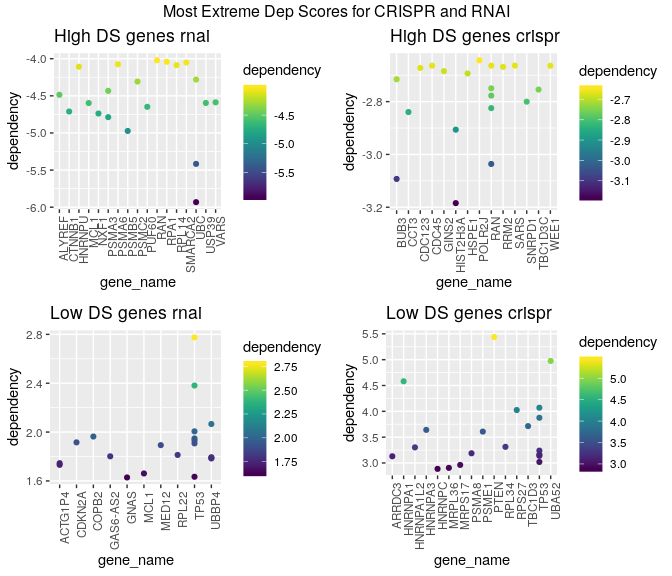

Compare the count of top 50 unique genes for `crispr` and `rnai` datasets for the most cancer-vitality inducing genes.

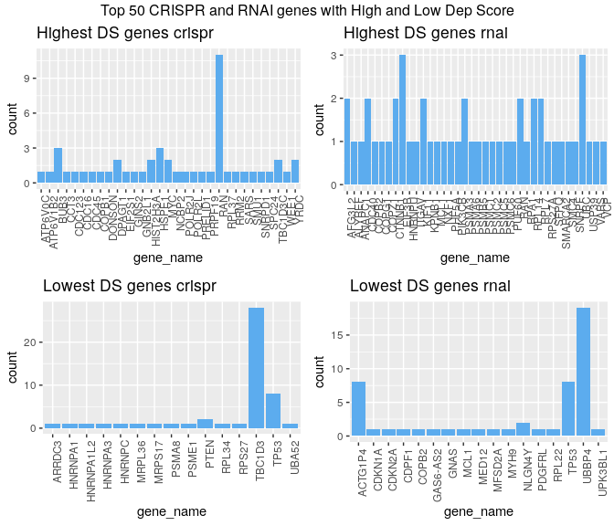

```
#> [1] "ID"
#> [2] "na.omit(each_log_copy_num_gene$mean_log_copy_number)"
```

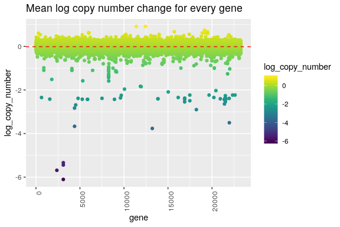

Find genes with greatest mean log copy number

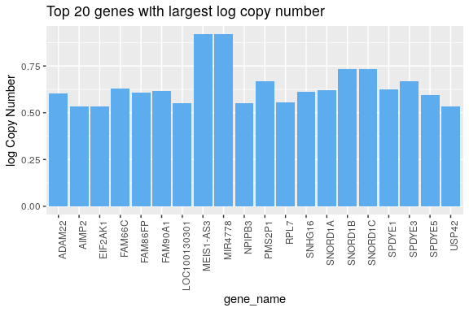